# (Flights EDA)

## Preliminary Wrangling

> This data is talking about the flights that happened in year 2008 and its delay reasons.

```python
# import all packages and set plots to be embedded inline
import numpy as np
import pandas as pd
import matplotlib.pyplot as plt
import seaborn as sb

%matplotlib inline
```

> Load in your dataset and describe its properties through the questions below. Try and motivate your exploration goals through this section.

```python
#Loading the data
df_8 = pd.read_csv("2008.csv")
df_8.info()
```

```
<class 'pandas.core.frame.DataFrame'>
RangeIndex: 7009728 entries, 0 to 7009727
Data columns (total 29 columns):
 #   Column             Dtype
---  ------             -----
 0   Year               int64
 1   Month              int64
 2   DayofMonth         int64
 3   DayOfWeek          int64
 4   DepTime            float64
 5   CRSDepTime         int64
 6   ArrTime            float64
 7   CRSArrTime         int64
 8   UniqueCarrier      object
 9   FlightNum          int64
```

[output cut: 21 more lines]

```python
df_8.shape
```

```
(7009728, 29)
```

### What is the structure of your dataset?

> The dataset has 7009728 rows (observations) and 29 Columns (features)

### What is/are the main feature(s) of interest in your dataset?

> DayofMonth,DayOfWeek,cancelled,delayed

### What features in the dataset do you think will help support your investigation into your feature(s) of interest?

> CarrierDelay,WeatherDelay,SecurityDelay

## Univariate Exploration

> In this section, investigate distributions of individual variables. If you see unusual points or outliers, take a deeper look to clean things up and prepare yourself to look at relationships between variables.

> Make sure that, after every plot or related series of plots, that you include a Markdown cell with comments about what you observed, and what you plan on investigating next.

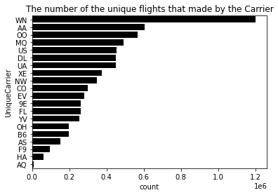

```python
# We will work on making the titles and the visualization.
sb.countplot(y='UniqueCarrier',data = df_8, color ='black',order = df_8['UniqueCarrier'].value_counts().index);
plt.title('The number of the unique flights that made by the Carrier')
```

If we looked to this chart we will notice that there is a difference in the number of the flights basd on the type of the carrier. And we have something like an outlier we will see with WN

### Discuss the distribution(s) of your variable(s) of interest. Were there any unusual points? Did you need to perform any transformations?

> No

### Of the features you investigated, were there any unusual distributions? Did you perform any operations on the data to tidy, adjust, or change the form of the data? If so, why did you do this?

> We may change the numbers of the days to its names but I left it

```python
df_8['UniqueCarrier' ].value_counts()
```

```
WN    1201754
AA     604885
OO     567159
MQ     490693
US     453589
DL     451931
UA     449515
XE     374510
NW     347652
CO     298455
EV     280575
9E     262208
FL     261684
YV     254930
OH     197607
B6     196091
AS     151102
F9      95762
HA      61826
AQ       7800
Name: UniqueCarrier, dtype: int64
```

> What is the best day of the month for the companies.

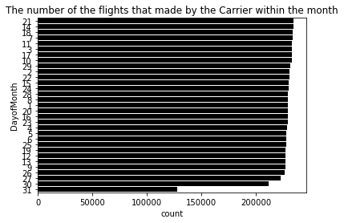

```python
#We will work on making the titles and the visualization.
sb.countplot(y='DayofMonth',data = df_8, color ='black', order = df_8['DayofMonth'].value_counts().index);
plt.title('The number of the flights that made by the Carrier within the month')
```

##### WE found that the best day of the month that has the biggest number of flights = 21 of the month

> What is the best day of the week for the companies.

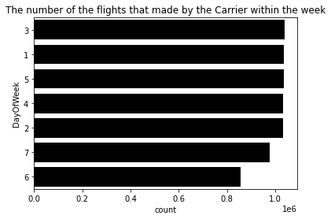

```python
#We will work on making the titles and the visualization.
sb.countplot(y='DayOfWeek',data = df_8, color ='black', order = df_8['DayOfWeek'].value_counts().index);
plt.title('The number of the flights that made by the Carrier within the week')
```

> If we looked only to the chart we will find that the days (3,1,5,4,2) have the same count of the flights so to be more specific we will look to it in numeric way.

```python
df_8['DayOfWeek'].value_counts()
```

```
3    1039665
1    1036201
5    1035166
4    1032224
2    1032049
7     976887
6     857536
Name: DayOfWeek, dtype: int64
```

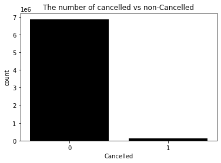

```python
#Here we will work on the visualization
sb.countplot(x='Cancelled',data = df_8, color ='black', order = df_8['Cancelled'].value_counts().index);
plt.title("The number of cancelled vs non-Cancelled")
```

[figure not shown]

```python
# or we can make the previous chart in pie chart with plt like this
plt.pie(df_8['Cancelled'].value_counts(),autopct='%.2f%%',labels=['Cancelled','Not Cancelled']);
plt.title('The ratio of the cancelled and non-Cancelled')
```

> Based on this chart we will know that the amount of cancelled flights is soooo small in comparison to the ones that didn't cancelled.

## Bivariate Exploration

> In this section, investigate relationships between pairs of variables in your data. Make sure the variables that you cover here have been introduced in some fashion in the previous section (univariate exploration).

```python
df_8.head()
```

|  | Year | Month | DayofMonth | DayOfWeek | DepTime | CRSDepTime | ArrTime | CRSArrTime | UniqueCarrier | FlightNum | ... | TaxiIn | TaxiOut | Cancelled | CancellationCode | Diverted | CarrierDelay | WeatherDelay | NASDelay | SecurityDelay | LateAircraftDelay |
| --- | --- | --- | --- | --- | --- | --- | --- | --- | --- | --- | --- | --- | --- | --- | --- | --- | --- | --- | --- | --- | --- |
| 0 | 2008 | 1 | 3 | 4 | 2003.0 | 1955 | 2211.0 | 2225 | WN | 335 | ... | 4.0 | 8.0 | 0 | NaN | 0 | NaN | NaN | NaN | NaN | NaN |
| 1 | 2008 | 1 | 3 | 4 | 754.0 | 735 | 1002.0 | 1000 | WN | 3231 | ... | 5.0 | 10.0 | 0 | NaN | 0 | NaN | NaN | NaN | NaN | NaN |
| 2 | 2008 | 1 | 3 | 4 | 628.0 | 620 | 804.0 | 750 | WN | 448 | ... | 3.0 | 17.0 | 0 | NaN | 0 | NaN | NaN | NaN | NaN | NaN |
| 3 | 2008 | 1 | 3 | 4 | 926.0 | 930 | 1054.0 | 1100 | WN | 1746 | ... | 3.0 | 7.0 | 0 | NaN | 0 | NaN | NaN | NaN | NaN | NaN |
| 4 | 2008 | 1 | 3 | 4 | 1829.0 | 1755 | 1959.0 | 1925 | WN | 3920 | ... | 3.0 | 10.0 | 0 | NaN | 0 | 2.0 | 0.0 | 0.0 | 0.0 | 32.0 |

5 rows × 29 columns

```python
dfweat = df_8[['Month', 'WeatherDelay']].groupby('Month').sum().reset_index()
```

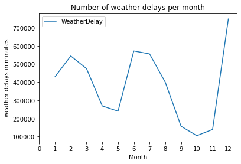

```python
#Here we will work on the visualization and give the axis its labels and names
dfweat.plot(x='Month', y='WeatherDelay' )
plt.xticks(list(range(0,13,1)))
plt.ylabel("weather delays in minutes")
plt.title("Number of weather delays per month")
plt.show()
```

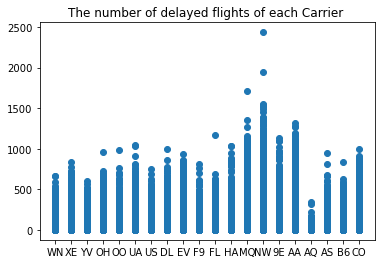

```python
plt.scatter(x= df_8['UniqueCarrier'],y = df_8['CarrierDelay']);
plt.title("The number of delayed flights of each Carrier ")
```

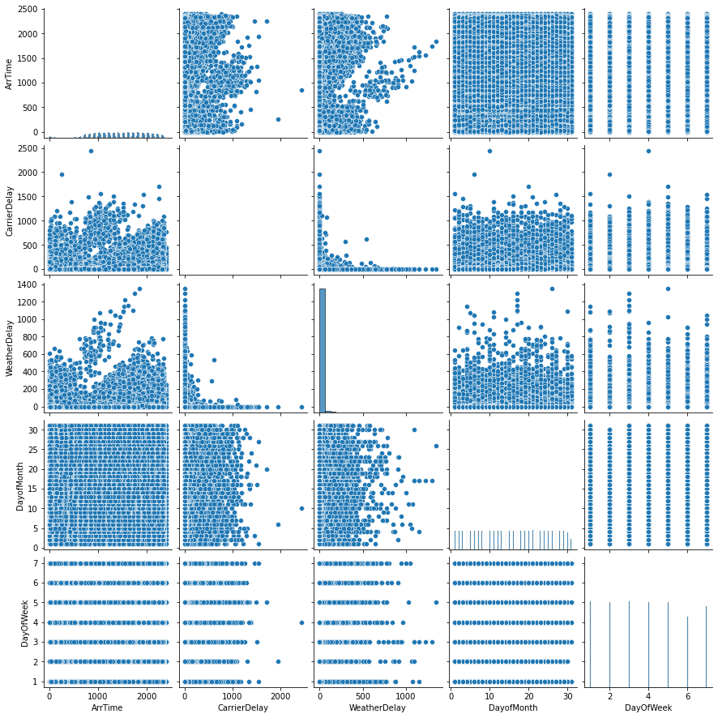

```python
sb.pairplot(df_8[['ArrTime','CarrierDelay','WeatherDelay','DayofMonth','DayOfWeek']]);
```

### Did you observe any interesting relationships between the other features (not the main feature(s) of interest)?

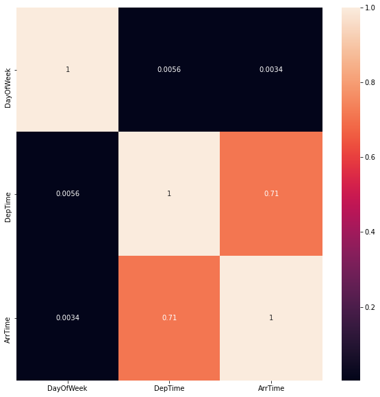

```python
#Here we will work on preparing the dataset which we will work on
df = df_8[['DayOfWeek','DepTime','ArrTime']]
df.head()

#WE will calculate the correlation and the visualization
df_corr = df.corr()
plt.figure(figsize=(10,10))
sb.heatmap(df_corr, annot=True)
plt.show()
```

## Multivariate Exploration

> Create plots of three or more variables to investigate your data even further. Make sure that your investigations are justified, and follow from your work in the previous sections.

> We will work on making a visualization between the departure time, the arrival time and the dayOfWeek to see if there any difference in the appointments that may affect the time

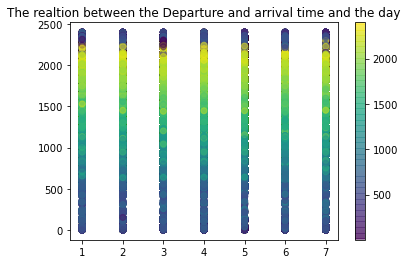

```python
# we will work on the visualization
plt.scatter(x=df.DayOfWeek, y=df.DepTime, alpha=.5, c=df.ArrTime)
plt.colorbar();
plt.title("The realtion between the Departure and arrival time and the day")
```

```python
#WE will wor on Data Preperation
delays = df_8[['DayofMonth','CarrierDelay', 'WeatherDelay',"NASDelay",'SecurityDelay','LateAircraftDelay']]
df1 = delays.dropna()
df1.isnull().sum()
```

```
DayofMonth           0
CarrierDelay         0
WeatherDelay         0
NASDelay             0
SecurityDelay        0
LateAircraftDelay    0
dtype: int64
```

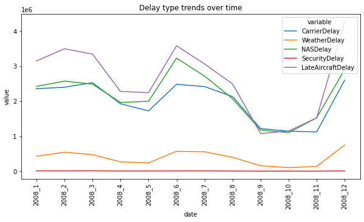

```python
# we will work on data preperation and choosing the right features that will be used
delays_over_time= df_8.drop(['UniqueCarrier','ArrDelay'],axis=1).groupby(['Year','Month']).sum().reset_index()
delays_over_time = pd.melt(delays_over_time, id_vars=['Year','Month'], value_vars=['CarrierDelay', 'WeatherDelay',"NASDelay",'SecurityDelay','LateAircraftDelay'])

#Converting the numbers to months and years
delays_over_time['date'] = delays_over_time['Year'].astype(str) +"_" +delays_over_time['Month'].astype(str)
delays_over_time = delays_over_time.drop(['Year','Month'], axis=1)

#Starting the Visualization Process
plt.figure(figsize=(10,5))
plt.title('Delay type trends over time')
plt.xticks(rotation=90)
sb.lineplot(x='date', y='value', hue='variable', data=delays_over_time)
plt.show()
```

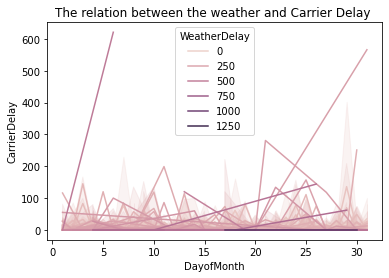

```python
sb.lineplot(x = 'DayofMonth',y='CarrierDelay',hue = 'WeatherDelay',data = delays);
plt.title("The relation between the weather and Carrier Delay ")
```

```python
#Choosing the right used features
tot_delays = df_8['WeatherDelay'].sum() + df_8['CarrierDelay'].sum()+df_8['SecurityDelay'].sum()+df_8['NASDelay'].sum()+df_8['LateAircraftDelay'].sum()

#MAking the calculations
wd = (df_8['WeatherDelay'].sum())/tot_delays
cd = (df_8['CarrierDelay'].sum())/tot_delays
sd = (df_8['SecurityDelay'].sum())/tot_delays
nd = (df_8['NASDelay'].sum())/tot_delays
ld = (df_8['LateAircraftDelay'].sum())/tot_delays
delay_ratios = [wd,cd,sd,nd,ld]
```

[figure not shown]

```python
#Make the visualization
lab = ['Weather Delays','Carrier Delays' , 'NAS Delays', 'Secuirity Delays','Late Air Craft']
plt.pie(delay_ratios,labels = lab, autopct='%.2f%%');
```

> If we looked to this chart we will specify the ratios of the reasons of the delay that may happen.

### Talk about some of the relationships you observed in this part of the investigation. Were there features that strengthened each other in terms of looking at your feature(s) of interest?

> Yeah, it helped us in finding the highest delay reasons.

### Were there any interesting or surprising interactions between features?

> At the end of your report, make sure that you export the notebook as an html file from the `File > Download as... > HTML` menu. Make sure you keep track of where the exported file goes, so you can put it in the same folder as this notebook for project submission. Also, make sure you remove all of the quote-formatted guide notes like this one before you finish your report!